# UNIDAD 5 Análisis exploratorio de documentos de texto mediante LSA

## Alumno: José Antonio García Casanova

# Introducción

Cuando se quiera analizar información no estructurada como lo son documentos, música, imágenes, etc., es necesario hacer uso de las técnicas de Procesamiento Natural del Lenguaje (PNL). Esta es una rama de las ciencias computacionales que tiene como propósito procesar el lenguaje natural.

Al igual que con la información estructurada es importante explorar los datos para que nos puedan brindar información acerca del comportamiento de nuestros datos.

```python
# Importamos las librerias necesarias
#======================================================
# import nltk
# nltk.download('stopwords')

# Importamos warnings
#======================================================
import warnings
warnings.filterwarnings('ignore')

# Importamos librerias básicas para NLP
#======================================================
import re
import nltk
import wordcloud
import seaborn as sns
import pandas as pd
import numpy as np
from collections import Counter
import matplotlib.pyplot as plt

# Importamos librerias personales
#======================================================
from utilidades import my_tokenizer, plotClusters

# Importamos librerias sklearn
#======================================================
from sklearn.feature_extraction.text import  CountVectorizer
from sklearn.feature_extraction.text import TfidfVectorizer
from sklearn.decomposition import TruncatedSVD
from sklearn.decomposition import LatentDirichletAllocation as LDiA
```

Cargamos nuestra base de datos, esta base de datos se compone de mensajes de tweets que han sido clasificados como de humor y no humor, también incluye una evaluación e indica el mecanismo de humor:

```python
data=pd.read_csv(filepath_or_buffer = "humor.csv",
                 delimiter = ',',
                 index_col = 0)

data.head(2)
```

| id | text | klass | humor_rating | humor_mechanism |
| --- | --- | --- | --- | --- |
| tweet1 | Niveles de retraso mental: \n\n— Bajo.\n— Medi... | joke | 1.5 | NaN |
| tweet2 | —Vamos Luke desenfunda tu sable, demuestra tu ... | joke | 1.5 | NaN |

## Matriz de termino documento por clase y por humor_mechanish

Generamos una matriz por clase, es decir, por joke y no-joke y también creamos una matriz basándonos en el mecanismo de humor.

### Clase: joke

Filtraremos por clase y crearemos la matriz utilizando el método de Bag Of Words y el método TF-IDF

```python
X_joke =data[data.klass=='joke'].text
```

#### Bag Of Words

```python
vectorizer = CountVectorizer(tokenizer=my_tokenizer).fit(X_joke)
bag_of_words = vectorizer.transform(X_joke)
sum_words = bag_of_words.sum(axis=0)
words_count_joke_bow = dict([(word, sum_words[0, idx]) for word, idx in vectorizer.vocabulary_.items()])
words_count_joke_bow = Counter(words_count_joke_bow)
```

Veamos cómo queda nuestro vector de término, para esto solo veremos los 5 más comunes:

```python
words_count_joke_bow.most_common(5)
```

```
[('mama', 737), ('chistes', 683), ('amor', 512), ('fb', 428), ('rt', 420)]
```

#### TF-IDF

```python
vectorizer = TfidfVectorizer(tokenizer=my_tokenizer).fit(X_joke)
bag_of_words = vectorizer.transform(X_joke)
sum_words=bag_of_words.sum(axis=0)
words_count_joke_tf = dict([(word, sum_words[0, idx]) for word, idx in vectorizer.vocabulary_.items()])
words_count_joke_tf=Counter(words_count_joke_tf)
```

Veamos cómo queda nuestro vector de término pero utilizando TF-IDF, para esto solo veremos los 5 más comunes:

```python
words_count_joke_tf.most_common(5)
```

```
[('mama', 128.41220181294108),
 ('chistes', 115.77713505936103),
 ('amor', 94.9211258866027),
 ('fb', 78.89848842127591),
 ('rt', 75.39084081430718)]
```

Como era de esperarse, el resultado no es el mismo ya que el método BOW utiliza solo el conteo de las ocurrencias para cada token, el método TF-IDF es una medida ponderada que busca ser más valiosa.

### Clase: no-joke

Realizamos el mismo ejercicio para la clase no-joke:

```python
X_no_joke =data[data.klass=='no-joke'].text
```

#### Bag Of Words

```python
vectorizer = CountVectorizer(tokenizer=my_tokenizer).fit(X_no_joke)
bag_of_words = vectorizer.transform(X_no_joke)
sum_words=bag_of_words.sum(axis=0)
words_count_no_joke_bow = dict([(word, sum_words[0, idx]) for word, idx in vectorizer.vocabulary_.items()])
words_count_no_joke_bow = Counter(words_count_no_joke_bow)
```

Veamos los tokens más comunes:

```python
words_count_no_joke_bow.most_common(5)
```

```
[('q', 532), ('quiero', 497), ('dia', 478), ('ser', 469), ('vida', 456)]
```

#### TF-IDF

```python
vectorizer = TfidfVectorizer(tokenizer=my_tokenizer).fit(X_no_joke)
bag_of_words = vectorizer.transform(X_no_joke)
sum_words=bag_of_words.sum(axis=0)
words_count_no_joke_tf = dict([(word, sum_words[0, idx]) for word, idx in vectorizer.vocabulary_.items()])
words_count_no_joke_tf=Counter(words_count_no_joke_tf)
```

Veamos los tokens más comunes para los tweets que son `no-joke` que han sido vectorizados por TF-IDF:

```python
words_count_no_joke_tf.most_common(5)
```

```
[('quiero', 133.9187882878201),
 ('dia', 119.10466352844077),
 ('vida', 110.83521098802518),
 ('q', 109.30080620002866),
 ('ser', 108.29901429280741)]
```

### Mecanismo de Humor

Para analizar el mecanismo de humor filtraremos por aquellos que no tienen mecanismo de humor, es decir, eliminaremos las filas que tengan NaN en humor_mechanism.

```python
X_mechanism = data.dropna(subset=['humor_mechanism']).text
```

#### Bag Of Words

```python
vectorizer = CountVectorizer(tokenizer=my_tokenizer).fit(X_mechanism)
bag_of_words = vectorizer.transform(X_mechanism)
sum_words=bag_of_words.sum(axis=0)
words_count_mechanism_bow = dict([(word, sum_words[0, idx]) for word, idx in vectorizer.vocabulary_.items()])
words_count_mechanism_bow = Counter(words_count_mechanism_bow)
```

Veamos el top 5:

```python
words_count_mechanism_bow.most_common(5)
```

```
[('mama', 416), ('chistes', 354), ('amor', 277), ('dice', 240), ('fb', 224)]
```

#### Mecanismo de Humor - TF-IDF

```python
vectorizer = TfidfVectorizer(tokenizer=my_tokenizer).fit(X_mechanism)
bag_of_words = vectorizer.transform(X_mechanism)
sum_words=bag_of_words.sum(axis=0)
words_count_mechanism_tf = dict([(word, sum_words[0, idx]) for word, idx in vectorizer.vocabulary_.items()])
words_count_mechanism_tf = Counter(words_count_mechanism_tf)
```

Veamos el top 5:

```python
words_count_mechanism_tf.most_common(5)
```

```
[('mama', 72.61798216680235),
 ('chistes', 62.46622849975757),
 ('amor', 51.09535422716811),
 ('dice', 43.704243092092796),
 ('fb', 41.98552966647391)]
```

## Análisis sobre las frecuencias de términos sobre los vectores

A continuación analizaremos las frecuencias de estos vectores, para esto nos ayudaremos del gráfico de barras y del gráfico nube de puntos.

### Clase: joke

#### Medidas estadísticas - BOW

```python
top=10
top_words_bows = [x[0] for x in words_count_joke_bow.most_common(top)]
values_bow = [x[1] for x in words_count_joke_bow.most_common(top)]

top=10
top_words_tf = [x[0] for x in words_count_joke_tf.most_common(top)]
values_tf = [x[1] for x in words_count_joke_tf.most_common(top)]
```

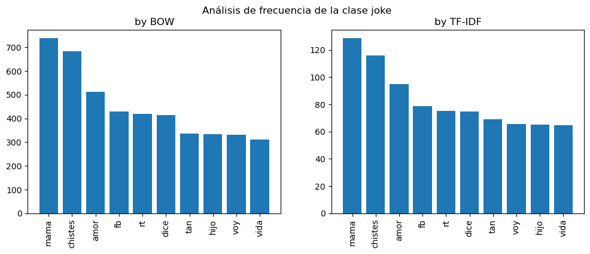

```python
fig, (ax1, ax2) = plt.subplots(1, 2)
fig.suptitle('Análisis de frecuencia de la clase joke')
fig.set_size_inches(12, 4)

ax1.bar(range(top), values_bow)
ax1.set_xticks(ticks=range(len(top_words_bows)),labels=top_words_bows,rotation='vertical')
ax1.set_title('by BOW');

ax2.bar(range(top), values_tf)
ax2.set_xticks(ticks=range(len(top_words_tf)),labels=top_words_tf,rotation='vertical')
ax2.set_title('by TF-IDF');
```

Podemos notar que ambos métodos tienen dentro de su top 10 los mismos tokens, sin embargo, es notorio el orden que establece en los últimos tokens, esta diferencia se puede explicar porque en BOW se considera la frecuencia de ocurrencia mientras que en TF-IDF es un peso ponderado.

### Clase: no-joke

```python
top=10
top_words_bows = [x[0] for x in words_count_no_joke_bow.most_common(top)]
values_bow = [x[1] for x in words_count_no_joke_bow.most_common(top)]

top=10
top_words_tf = [x[0] for x in words_count_no_joke_tf.most_common(top)]
values_tf = [x[1] for x in words_count_no_joke_tf.most_common(top)]
```

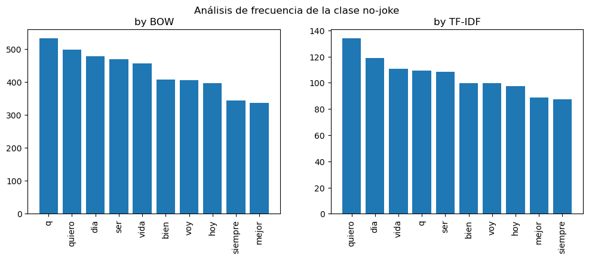

```python
fig, (ax1, ax2) = plt.subplots(1, 2)
fig.suptitle('Análisis de frecuencia de la clase no-joke')
fig.set_size_inches(12, 4)

ax1.bar(range(top), values_bow)
ax1.set_xticks(ticks=range(len(top_words_bows)),labels = top_words_bows, rotation = 'vertical')
ax1.set_title('by BOW');

ax2.bar(range(top), values_tf)
ax2.set_xticks(ticks=range(len(top_words_tf)),labels = top_words_tf, rotation = 'vertical')
ax2.set_title('by TF-IDF');
```

A diferencia de la clase **joke**, en **no-joke** vemos que la letra `q` se encuentra en primer lugar para BOW, sin embargo, esto no nos dice mucho. Por su parte TF-IDF cambia el orden y en primer lugar aparece la palabra `quiero` en primer lugar.

### Mecanismo de humor

```python
top=10
top_words_bows = [x[0] for x in words_count_mechanism_bow.most_common(top)]
values_bow = [x[1] for x in words_count_mechanism_bow.most_common(top)]

top=10
top_words_tf = [x[0] for x in words_count_mechanism_tf.most_common(top)]
values_tf = [x[1] for x in words_count_mechanism_tf.most_common(top)]
```

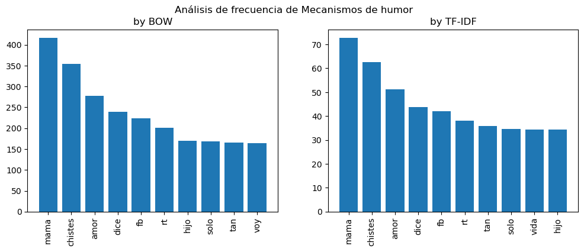

```python
fig, (ax1, ax2) = plt.subplots(1, 2)
fig.suptitle('Análisis de frecuencia de Mecanismos de humor')
fig.set_size_inches(12, 4)

ax1.bar(range(top), values_bow)
ax1.set_xticks(ticks=range(len(top_words_bows)),labels=top_words_bows,rotation='vertical')
ax1.set_title('by BOW');

ax2.bar(range(top), values_tf)
ax2.set_xticks(ticks=range(len(top_words_tf)),labels=top_words_tf,rotation='vertical')
ax2.set_title('by TF-IDF');
```

#### Nubes de palabras

Nube de palabras es un gráfico que nos permite visualizar cuales son las palabras más relevantes dentro de un conjunto de datos. La relevancia de estas palabras es mostrada por el tamaño de letra, a mayor relevancia mayor será el tamaño de su letra en el gráfico.

#### Clase: joke

##### BOW

[figure not shown]

```python
vectorizer = CountVectorizer(tokenizer=my_tokenizer).fit(X_joke)
bag_of_words = vectorizer.transform(X_joke)

#obtener la frecuencia de cada palabra
sum_words = bag_of_words.sum(axis=0) # sumas la frecuencia de todas las palabras
#obtenemos cada termino y lo mapeamos
words_count = Counter(dict([(word, sum_words[0, idx]) for word, idx in vectorizer.vocabulary_.items()]))

#Obtenemos una nube similar
wc=wordcloud.WordCloud()
wc.generate_from_frequencies(dict(words_count.most_common(100)))
plt.imshow(wc)
plt.axis("off")
plt.show()
```

##### TF-IDF

[figure not shown]

```python
vectorizer = TfidfVectorizer(tokenizer=my_tokenizer).fit(X_joke)
bag_of_words = vectorizer.transform(X_joke)

#obtener la frecuencia de cada palabra
sum_words = bag_of_words.sum(axis=0) # sumas la frecuencia de todas las palabras
#obtenemos cada termino y lo mapeamos
words_count = Counter(dict([(word, sum_words[0, idx]) for word, idx in vectorizer.vocabulary_.items()]))

#Obtenemos una nube similar
wc=wordcloud.WordCloud()
wc.generate_from_frequencies(dict(words_count.most_common(100)))
plt.imshow(wc)
plt.axis("off")
plt.show()
```

#### Clase: no-joke

##### BOW

[figure not shown]

```python
vectorizer = CountVectorizer(tokenizer=my_tokenizer).fit(X_no_joke)
bag_of_words = vectorizer.transform(X_no_joke)

#obtener la frecuencia de cada palabra
sum_words = bag_of_words.sum(axis=0) # sumas la frecuencia de todas las palabras
#obtenemos cada termino y lo mapeamos
words_count = Counter(dict([(word, sum_words[0, idx]) for word, idx in vectorizer.vocabulary_.items()]))

#Obtenemos una nube similar
wc=wordcloud.WordCloud()
wc.generate_from_frequencies(dict(words_count.most_common(100)))
plt.imshow(wc)
plt.axis("off")
plt.show()
```

##### TF-IDF

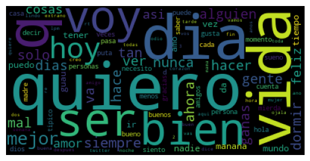

```python
vectorizer = TfidfVectorizer(tokenizer=my_tokenizer).fit(X_no_joke)
bag_of_words = vectorizer.transform(X_no_joke)

#obtener la frecuencia de cada palabra
sum_words = bag_of_words.sum(axis=0) # sumas la frecuencia de todas las palabras
#obtenemos cada termino y lo mapeamos
words_count = Counter(dict([(word, sum_words[0, idx]) for word, idx in vectorizer.vocabulary_.items()]))

#Obtenemos una nube similar
wc=wordcloud.WordCloud()
wc.generate_from_frequencies(dict(words_count.most_common(100)))
plt.imshow(wc)
plt.axis("off")
plt.show()
```

### Mecanismo de Humor

##### BOW

[figure not shown]

```python
vectorizer = CountVectorizer(tokenizer=my_tokenizer).fit(X_mechanism)
bag_of_words = vectorizer.transform(X_mechanism)

#obtener la frecuencia de cada palabra
sum_words = bag_of_words.sum(axis=0) # sumas la frecuencia de todas las palabras
#obtenemos cada termino y lo mapeamos
words_count = Counter(dict([(word, sum_words[0, idx]) for word, idx in vectorizer.vocabulary_.items()]))

#Obtenemos una nube similar
wc=wordcloud.WordCloud()
wc.generate_from_frequencies(dict(words_count.most_common(100)))
plt.imshow(wc)
plt.axis("off")
plt.show()
```

##### TF-IDF

[figure not shown]

```python
vectorizer = TfidfVectorizer(tokenizer=my_tokenizer).fit(X_mechanism)
bag_of_words = vectorizer.transform(X_mechanism)

#obtener la frecuencia de cada palabra
sum_words = bag_of_words.sum(axis=0) # sumas la frecuencia de todas las palabras
#obtenemos cada termino y lo mapeamos
words_count = Counter(dict([(word, sum_words[0, idx]) for word, idx in vectorizer.vocabulary_.items()]))

#Obtenemos una nube similar
wc=wordcloud.WordCloud()
wc.generate_from_frequencies(dict(words_count.most_common(100)))
plt.imshow(wc)
plt.axis("off")
plt.show()
```

## Reducción de dimensión Latent Dirichlet Allocation (LDiA) y TruncateSVD

En Latent Dirichlet Allocation las observaciones se recopilan en documentos y a cada palabra se le atribuye un tema. Por su parte, Singular Value Descomposition (SVD) es un método que factoriza una matriz en tres matrices, permitiendo en el paso hacer reducción o transformaciones a los datos.

Para elegir el número de temas a crear utilizaremos el campo mecanismos de humor + 1 ya que el campo es una referencia a los temas.

#### Clase: joke

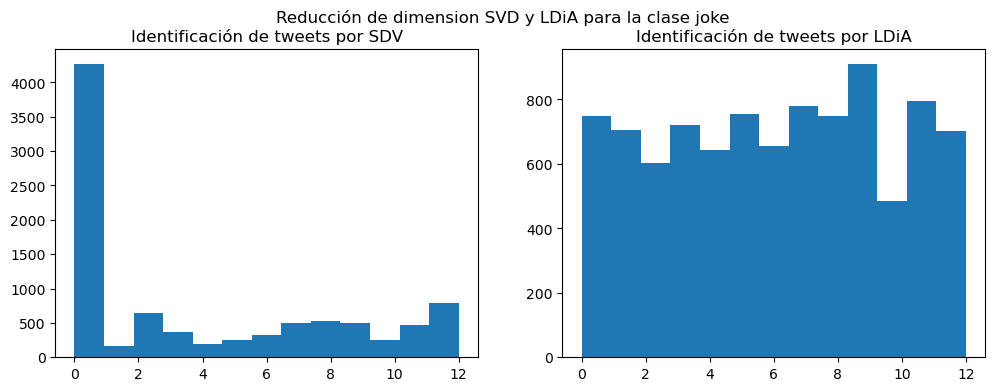

```python
fig, (ax1, ax2) = plt.subplots(1, 2)
fig.suptitle('Reducción de dimension SVD y LDiA para la clase joke \n')
fig.set_size_inches(12, 4)

nt = data.humor_mechanism.value_counts().value_counts().sum() + 1

#======================================= SDV
vectorizer = TfidfVectorizer(tokenizer = my_tokenizer).fit(X_joke)
vtfid = vectorizer.transform(raw_documents = X_joke)

svd = TruncatedSVD(n_components=nt, n_iter=100)
vectores_de_topicos_svd = svd.fit_transform(vtfid)
topicos=[f'tema{str(i+1).zfill(2)}' for i in range(nt)]
cols_num, terms_bow=zip(*sorted(zip(vectorizer.vocabulary_.values(), vectorizer.vocabulary_.keys())))

componentes_sdv=pd.DataFrame(svd.components_.T,columns=topicos,index=terms_bow)

tweet_topico = np.argmax(vectores_de_topicos_svd,axis=1)

ax1.hist(tweet_topico, bins=nt)
# ax1.set_xticks(ticks=range(len(top_words_bows)),labels = top_words_bows, rotation = 'vertical')
ax1.set_title('Identificación de tweets por SDV')


#======================================= LDiA
counter = CountVectorizer(tokenizer=my_tokenizer)
vsm = counter.fit_transform(raw_documents=X_joke)
cols_num,terms_bow=zip(*sorted(zip(counter.vocabulary_.values(), counter.vocabulary_.keys())))
tweets_bows=pd.DataFrame(vsm.toarray(),index=[f't{i}' for i in range(len(X_joke))], columns=terms_bow)

ldia = LDiA(n_components=nt)
vectores_de_topicos_ldia = ldia.fit_transform(tweets_bows)

#  Matrix palabra topico
topicos=[f'tema{str(i+1).zfill(2)}' for i in range(nt)]
componentes_ldia = pd.DataFrame(ldia.components_.T, index=terms_bow, columns=topicos)

tweet_temas=np.argmax(vectores_de_topicos_ldia,axis=1)
ax2.hist(tweet_temas, bins=nt)
# ax2.set_xticks(ticks=range(len(top_words_tf)),labels = top_words_tf, rotation = 'vertical')
ax2.set_title('Identificación de tweets por LDiA');
```

La reducción por SDV muestra una concentración de temas por tweet en el tema 0, por su parte la reducción por LDiA muestra una mayor distribución de tweets en los diferentes temas, lo cual hace sentido al ver el conteo de mecanismo de humor y su conteo de valores.

```python
data.humor_mechanism.value_counts()
```

```
wordplay            701
reference           578
absurd              566
exaggeration        476
unmasking           441
misunderstanding    416
irony               371
analogy             319
embarrassment       301
parody              255
stereotype          230
insults             146
Name: humor_mechanism, dtype: int64
```

#### Frecuencia de palabras por Tema

Para esto guardaremos los valores ordenados, los uniremos y los mostraremos en un único dataframe:

##### SDV

```python
tema1 = componentes_sdv.tema01.sort_values(ascending=False)[:10]
tema2 = componentes_sdv.tema02.sort_values(ascending=False)[:10]
tema3 = componentes_sdv.tema03.sort_values(ascending=False)[:10]
tema4 = componentes_sdv.tema04.sort_values(ascending=False)[:10]
tema5 = componentes_sdv.tema05.sort_values(ascending=False)[:10]
tema6 = componentes_sdv.tema06.sort_values(ascending=False)[:10]
tema7 = componentes_sdv.tema07.sort_values(ascending=False)[:10]
tema8 = componentes_sdv.tema08.sort_values(ascending=False)[:10]
tema9 = componentes_sdv.tema09.sort_values(ascending=False)[:10]
tema10 = componentes_sdv.tema10.sort_values(ascending=False)[:10]
tema11 = componentes_sdv.tema11.sort_values(ascending=False)[:10]
tema12 = componentes_sdv.tema12.sort_values(ascending=False)[:10]
tema13 = componentes_sdv.tema13.sort_values(ascending=False)[:10]

frecuancia_palabra_temas = pd.DataFrame(tema1).join(tema2, how='outer').join(tema3, how='outer').join(tema4, how='outer') \
                                                .join(tema5, how='outer').join(tema6, how='outer').join(tema7, how='outer') \
                                                .join(tema8, how='outer').join(tema9, how='outer').join(tema10, how='outer') \
                                                .join(tema11, how='outer').join(tema12, how='outer').join(tema13, how='outer')

frecuancia_palabra_temas
```

|  | tema01 | tema02 | tema03 | tema04 | tema05 | tema06 | tema07 | tema08 | tema09 | tema10 | tema11 | tema12 | tema13 |
| --- | --- | --- | --- | --- | --- | --- | --- | --- | --- | --- | --- | --- | --- |
| 1 | NaN | NaN | NaN | NaN | NaN | NaN | 0.282187 | NaN | NaN | NaN | NaN | NaN | NaN |
| 2 | NaN | NaN | NaN | NaN | NaN | NaN | 0.322960 | NaN | NaN | NaN | NaN | NaN | NaN |
| 3 | NaN | NaN | NaN | NaN | NaN | NaN | 0.310182 | NaN | NaN | NaN | NaN | NaN | NaN |
| 4 | NaN | NaN | NaN | NaN | NaN | NaN | 0.138139 | NaN | NaN | NaN | NaN | NaN | NaN |
| adoptado | NaN | 0.027274 | NaN | NaN | NaN | NaN | NaN | NaN | NaN | NaN | NaN | NaN | NaN |
| ah | NaN | NaN | NaN | NaN | NaN | NaN | NaN | NaN | NaN | NaN | NaN | 0.086306 | NaN |
| amor | 0.183182 | NaN | NaN | 0.701897 | 0.157155 | 0.170822 | 0.171540 | NaN | NaN | NaN | 0.074158 | NaN | NaN |
| anecdotas | NaN | NaN | 0.056572 | NaN | NaN | NaN | NaN | NaN | NaN | NaN | NaN | NaN | NaN |
| anos | NaN | NaN | NaN | NaN | NaN | NaN | NaN | NaN | NaN | NaN | NaN | NaN | 0.127823 |
| bien | NaN | NaN | NaN | NaN | NaN | NaN | NaN | 0.109357 | NaN | 0.154848 | NaN | 0.403163 | 0.158763 |
| callate | NaN | 0.022540 | NaN | NaN | NaN | NaN | NaN | NaN | NaN | NaN | NaN | NaN | NaN |
| casa | NaN | NaN | NaN | NaN | NaN | NaN | NaN | 0.116421 | NaN | NaN | NaN | 0.163482 | NaN |
| chiste | 0.158104 | NaN | 0.341552 | 0.084801 | 0.059351 | NaN | NaN | NaN | 0.073573 | NaN | NaN | NaN | NaN |
| chistes | 0.248486 | NaN | 0.642688 | 0.060139 | NaN | NaN | NaN | NaN | NaN | NaN | NaN | NaN | NaN |
| colegio | NaN | 0.062237 | NaN | NaN | NaN | NaN | NaN | NaN | NaN | NaN | NaN | NaN | NaN |
| dia | NaN | NaN | NaN | NaN | NaN | NaN | NaN | 0.145101 | NaN | NaN | NaN | NaN | 0.175184 |
| dice | 0.139212 | NaN | 0.097090 | NaN | 0.045468 | NaN | NaN | NaN | 0.426312 | NaN | 0.550100 | 0.237638 | NaN |
| dicen | 0.119856 | 0.118781 | NaN | NaN | NaN | NaN | NaN | NaN | NaN | NaN | NaN | NaN | NaN |
| dijo | NaN | NaN | 0.029587 | NaN | NaN | NaN | NaN | NaN | NaN | NaN | NaN | NaN | NaN |
| dime | NaN | NaN | NaN | 0.039157 | NaN | NaN | NaN | NaN | NaN | NaN | NaN | NaN | NaN |
| doctor | NaN | NaN | NaN | NaN | NaN | NaN | NaN | NaN | 0.046878 | NaN | NaN | NaN | NaN |
| dormir | NaN | NaN | NaN | NaN | NaN | NaN | NaN | 0.118084 | NaN | NaN | NaN | NaN | NaN |
| dos | NaN | NaN | NaN | NaN | NaN | NaN | NaN | NaN | NaN | NaN | NaN | 0.098293 | 0.130077 |
| escuela | NaN | 0.103240 | NaN | NaN | NaN | NaN | NaN | NaN | NaN | NaN | NaN | NaN | NaN |
| fb | NaN | NaN | NaN | NaN | NaN | 0.078054 | NaN | NaN | 0.153999 | 0.065249 | NaN | NaN | NaN |
| fea | NaN | NaN | 0.025809 | NaN | NaN | 0.112383 | NaN | NaN | NaN | NaN | NaN | NaN | NaN |
| feo | NaN | NaN | NaN | NaN | NaN | 0.089522 | NaN | NaN | NaN | NaN | NaN | NaN | NaN |
| frases | NaN | NaN | 0.035069 | NaN | NaN | NaN | NaN | NaN | NaN | NaN | NaN | NaN | NaN |
| gorda | NaN | NaN | NaN | 0.073060 | NaN | 0.067126 | NaN | NaN | NaN | NaN | NaN | NaN | NaN |
| grande | NaN | NaN | NaN | NaN | NaN | 0.039644 | NaN | NaN | NaN | NaN | NaN | NaN | NaN |
| hace | NaN | NaN | NaN | NaN | NaN | NaN | NaN | NaN | NaN | NaN | NaN | NaN | 0.145539 |
| hijo | 0.175087 | 0.112402 | NaN | NaN | 0.207998 | 0.183245 | NaN | NaN | NaN | NaN | NaN | NaN | 0.132870 |
| hola | NaN | NaN | NaN | NaN | NaN | NaN | NaN | 0.094344 | NaN | 0.127956 | NaN | 0.204423 | 0.096880 |
| hombre | NaN | NaN | NaN | NaN | NaN | NaN | NaN | NaN | 0.079279 | NaN | NaN | NaN | NaN |
| humor | NaN | NaN | 0.190439 | NaN | NaN | NaN | NaN | NaN | NaN | NaN | NaN | NaN | NaN |
| jajaja | NaN | NaN | NaN | 0.043300 | 0.071006 | NaN | 0.155182 | 0.151757 | 0.300259 | NaN | NaN | NaN | NaN |
| llaman | NaN | 0.029395 | NaN | NaN | NaN | NaN | NaN | NaN | NaN | NaN | NaN | NaN | NaN |
| madre | NaN | NaN | NaN | NaN | NaN | NaN | NaN | NaN | NaN | NaN | 0.055767 | NaN | NaN |
| mama | 0.522179 | 0.729462 | NaN | 0.138453 | NaN | NaN | NaN | NaN | NaN | NaN | 0.053420 | NaN | NaN |
| mujer | NaN | NaN | NaN | NaN | NaN | NaN | NaN | NaN | 0.150644 | NaN | NaN | NaN | NaN |
| mujeres | NaN | NaN | NaN | NaN | NaN | NaN | NaN | NaN | NaN | 0.075979 | NaN | 0.082558 | NaN |
| novia | NaN | NaN | NaN | NaN | NaN | NaN | NaN | NaN | NaN | 0.163168 | NaN | 0.098052 | 0.119013 |
| novio | NaN | NaN | NaN | NaN | NaN | 0.038497 | NaN | NaN | NaN | NaN | NaN | NaN | NaN |
| oye | NaN | NaN | NaN | NaN | NaN | NaN | NaN | NaN | NaN | 0.153388 | NaN | 0.118486 | NaN |
| papa | 0.165319 | 0.060708 | NaN | NaN | 0.614126 | 0.387149 | 0.165089 | NaN | NaN | NaN | NaN | NaN | NaN |
| preguntale | NaN | 0.021081 | NaN | NaN | NaN | NaN | NaN | NaN | NaN | NaN | NaN | NaN | NaN |
| pues | NaN | NaN | NaN | NaN | 0.047088 | NaN | NaN | NaN | NaN | NaN | NaN | NaN | NaN |
| puta | NaN | NaN | NaN | NaN | NaN | NaN | NaN | NaN | NaN | NaN | NaN | 0.096490 | 0.084610 |
| quieres | NaN | NaN | NaN | NaN | NaN | NaN | NaN | NaN | NaN | 0.116833 | NaN | NaN | NaN |
| quiero | NaN | NaN | NaN | NaN | 0.041479 | NaN | NaN | NaN | NaN | 0.457243 | 0.152790 | NaN | NaN |
| rt | 0.198671 | NaN | 0.357017 | 0.131935 | 0.096427 | NaN | 0.200942 | 0.183903 | 0.290648 | NaN | NaN | NaN | NaN |
| ser | NaN | NaN | NaN | NaN | NaN | NaN | NaN | 0.185871 | NaN | 0.414192 | 0.351678 | NaN | NaN |
| solo | NaN | NaN | NaN | NaN | NaN | NaN | NaN | NaN | NaN | 0.146210 | NaN | NaN | NaN |
| tan | NaN | NaN | 0.103613 | NaN | NaN | 0.554605 | 0.323756 | NaN | NaN | NaN | 0.128672 | NaN | NaN |
| tipico | NaN | NaN | NaN | NaN | NaN | NaN | NaN | NaN | 0.047107 | NaN | NaN | NaN | NaN |
| va | NaN | NaN | NaN | NaN | NaN | NaN | NaN | NaN | NaN | NaN | 0.117597 | NaN | NaN |
| vida | NaN | NaN | NaN | 0.088605 | NaN | NaN | NaN | NaN | NaN | NaN | 0.140108 | NaN | 0.445448 |
| voy | NaN | NaN | NaN | NaN | NaN | NaN | NaN | 0.327574 | NaN | NaN | 0.068216 | NaN | NaN |
| xd | 0.116404 | NaN | NaN | 0.076996 | 0.086045 | NaN | 0.213449 | 0.222183 | 0.419293 | NaN | NaN | NaN | NaN |

##### LDiA

```python
tema1 = componentes_ldia.tema01.sort_values(ascending=False)[:10]
tema2 = componentes_ldia.tema02.sort_values(ascending=False)[:10]
tema3 = componentes_ldia.tema03.sort_values(ascending=False)[:10]
tema4 = componentes_ldia.tema04.sort_values(ascending=False)[:10]
tema5 = componentes_ldia.tema05.sort_values(ascending=False)[:10]
tema6 = componentes_ldia.tema06.sort_values(ascending=False)[:10]
tema7 = componentes_ldia.tema07.sort_values(ascending=False)[:10]
tema8 = componentes_ldia.tema08.sort_values(ascending=False)[:10]
tema9 = componentes_ldia.tema09.sort_values(ascending=False)[:10]
tema10 = componentes_ldia.tema10.sort_values(ascending=False)[:10]
tema11 = componentes_ldia.tema11.sort_values(ascending=False)[:10]
tema12 = componentes_ldia.tema12.sort_values(ascending=False)[:10]
tema13 = componentes_ldia.tema13.sort_values(ascending=False)[:10]

frecuancia_palabra_temas = pd.DataFrame(tema1).join(tema2, how='outer').join(tema3, how='outer').join(tema4, how='outer') \
                                                .join(tema5, how='outer').join(tema6, how='outer').join(tema7, how='outer') \
                                                .join(tema8, how='outer').join(tema9, how='outer').join(tema10, how='outer') \
                                                .join(tema11, how='outer').join(tema12, how='outer').join(tema13, how='outer')

frecuancia_palabra_temas.head(60)
```

|  | tema01 | tema02 | tema03 | tema04 | tema05 | tema06 | tema07 | tema08 | tema09 | tema10 | tema11 | tema12 | tema13 |
| --- | --- | --- | --- | --- | --- | --- | --- | --- | --- | --- | --- | --- | --- |
| ... | NaN | NaN | NaN | NaN | NaN | NaN | NaN | NaN | 50.686357 | NaN | NaN | NaN | NaN |
| 1 | NaN | NaN | 43.952694 | NaN | NaN | NaN | NaN | NaN | NaN | NaN | NaN | NaN | 36.825455 |
| 14 | NaN | NaN | NaN | NaN | NaN | NaN | NaN | NaN | NaN | NaN | 25.886170 | NaN | NaN |
| 2 | NaN | NaN | NaN | NaN | NaN | NaN | NaN | NaN | NaN | NaN | NaN | 43.493144 | 49.087710 |
| 3 | NaN | NaN | 36.871236 | NaN | NaN | NaN | NaN | NaN | NaN | NaN | NaN | NaN | 43.902563 |
| 5 | NaN | NaN | NaN | NaN | NaN | NaN | NaN | NaN | NaN | NaN | NaN | 44.204993 | NaN |
| ahora | NaN | NaN | 28.701942 | NaN | NaN | NaN | NaN | NaN | NaN | NaN | NaN | NaN | NaN |
| amigos | NaN | 47.134576 | NaN | NaN | NaN | NaN | NaN | NaN | NaN | NaN | NaN | NaN | NaN |
| amo | NaN | NaN | NaN | NaN | NaN | NaN | NaN | NaN | NaN | NaN | NaN | NaN | 43.074070 |
| amor | NaN | NaN | 33.229745 | 38.894770 | 80.189707 | 41.725906 | 36.781224 | 133.671279 | NaN | NaN | NaN | NaN | NaN |
| ano | NaN | NaN | NaN | NaN | NaN | 46.498657 | NaN | NaN | NaN | NaN | NaN | NaN | NaN |
| anos | NaN | NaN | NaN | NaN | NaN | NaN | NaN | NaN | NaN | NaN | NaN | 103.945756 | NaN |
| asi | NaN | NaN | NaN | NaN | NaN | NaN | NaN | NaN | NaN | NaN | NaN | NaN | 36.610357 |
| bien | NaN | NaN | NaN | NaN | NaN | NaN | NaN | NaN | NaN | 69.900175 | 32.243905 | NaN | NaN |
| buena | NaN | 47.045799 | NaN | NaN | NaN | NaN | NaN | NaN | NaN | NaN | NaN | NaN | NaN |
| buenas | NaN | NaN | 30.464272 | NaN | NaN | NaN | NaN | NaN | NaN | NaN | NaN | NaN | NaN |
| casa | NaN | NaN | NaN | NaN | NaN | NaN | NaN | 37.601304 | NaN | 59.708616 | NaN | NaN | NaN |
| chiste | NaN | NaN | NaN | NaN | 37.720768 | NaN | NaN | 54.616884 | NaN | 109.010999 | NaN | NaN | NaN |
| chistes | NaN | 36.143655 | NaN | 112.527235 | 54.165903 | NaN | NaN | 107.266325 | 56.090953 | 144.402647 | NaN | NaN | 39.068499 |
| comer | NaN | NaN | NaN | NaN | 39.959706 | NaN | NaN | NaN | NaN | NaN | NaN | NaN | NaN |
| corazon | NaN | NaN | NaN | NaN | NaN | NaN | NaN | NaN | NaN | NaN | 31.740499 | NaN | NaN |
| da | NaN | NaN | NaN | NaN | NaN | 44.919790 | NaN | NaN | NaN | NaN | NaN | NaN | NaN |
| dias | NaN | NaN | NaN | NaN | NaN | NaN | NaN | NaN | NaN | NaN | NaN | 40.109891 | NaN |
| dice | NaN | NaN | NaN | 176.979117 | NaN | NaN | NaN | 38.811003 | NaN | NaN | NaN | NaN | NaN |
| dicen | NaN | NaN | NaN | NaN | NaN | NaN | NaN | NaN | NaN | 123.990205 | NaN | NaN | NaN |
| dijo | NaN | NaN | NaN | NaN | NaN | NaN | NaN | 55.735855 | NaN | NaN | NaN | NaN | NaN |
| dinero | NaN | NaN | NaN | NaN | 34.424547 | NaN | NaN | NaN | NaN | NaN | NaN | NaN | NaN |
| doctor | NaN | NaN | NaN | NaN | NaN | NaN | NaN | NaN | 61.027596 | NaN | NaN | NaN | NaN |
| dormir | NaN | 38.517473 | NaN | NaN | NaN | NaN | NaN | NaN | NaN | NaN | NaN | NaN | NaN |
| dos | NaN | NaN | 30.084445 | 64.034620 | NaN | NaN | NaN | NaN | NaN | NaN | NaN | NaN | NaN |
| escuela | NaN | NaN | NaN | NaN | NaN | NaN | NaN | NaN | NaN | 96.965172 | NaN | NaN | NaN |
| favor | NaN | NaN | NaN | NaN | NaN | NaN | NaN | NaN | NaN | NaN | NaN | NaN | 30.993090 |
| fb | 65.225512 | 35.764722 | NaN | NaN | NaN | 61.660150 | NaN | NaN | 68.038017 | NaN | NaN | 39.703007 | NaN |
| febrero | NaN | NaN | NaN | NaN | NaN | NaN | NaN | NaN | NaN | NaN | 22.051193 | NaN | NaN |
| hace | NaN | NaN | NaN | NaN | NaN | NaN | NaN | NaN | NaN | NaN | NaN | 73.902867 | NaN |
| hacer | NaN | NaN | 52.060730 | NaN | NaN | NaN | NaN | NaN | NaN | NaN | NaN | NaN | NaN |
| hijo | NaN | NaN | NaN | NaN | NaN | NaN | 48.229707 | NaN | NaN | 100.877678 | NaN | NaN | NaN |
| hola | NaN | NaN | NaN | NaN | 48.463284 | NaN | NaN | NaN | 48.734980 | NaN | NaN | NaN | NaN |
| hoy | NaN | NaN | NaN | NaN | NaN | NaN | NaN | NaN | NaN | NaN | 37.199081 | NaN | NaN |
| ja | NaN | NaN | NaN | NaN | NaN | NaN | NaN | NaN | 123.076922 | NaN | NaN | NaN | NaN |
| jajaja | NaN | NaN | NaN | NaN | 46.412414 | NaN | 61.693027 | NaN | NaN | NaN | NaN | NaN | NaN |
| mama | NaN | NaN | NaN | 40.827323 | 50.287224 | NaN | NaN | NaN | NaN | 480.607441 | NaN | 84.868317 | NaN |
| manana | NaN | NaN | NaN | NaN | NaN | NaN | 57.136602 | NaN | NaN | NaN | NaN | NaN | NaN |
| mejor | 35.035565 | NaN | NaN | NaN | NaN | NaN | NaN | NaN | NaN | NaN | NaN | NaN | NaN |
| mujer | NaN | NaN | NaN | NaN | NaN | 36.415235 | NaN | 61.026107 | NaN | NaN | NaN | NaN | NaN |
| mujeres | NaN | NaN | NaN | NaN | NaN | 56.766147 | NaN | NaN | NaN | NaN | NaN | NaN | NaN |
| novia | NaN | NaN | NaN | NaN | NaN | NaN | NaN | NaN | 60.101996 | NaN | NaN | NaN | NaN |
| novio | NaN | 52.794672 | NaN | NaN | NaN | NaN | NaN | NaN | NaN | NaN | NaN | NaN | NaN |
| ok | NaN | NaN | NaN | NaN | NaN | NaN | NaN | NaN | NaN | NaN | 56.702513 | NaN | NaN |
| oye | NaN | 35.197505 | 29.696834 | NaN | NaN | NaN | NaN | NaN | NaN | NaN | NaN | NaN | NaN |
| papa | NaN | NaN | NaN | NaN | NaN | 40.684702 | 67.779425 | NaN | 55.597456 | 65.127182 | NaN | NaN | NaN |
| pendejo | 40.068632 | NaN | NaN | NaN | NaN | NaN | NaN | NaN | NaN | NaN | NaN | NaN | NaN |
| puedo | NaN | NaN | NaN | NaN | NaN | NaN | NaN | NaN | NaN | NaN | 24.227873 | NaN | NaN |
| pues | NaN | NaN | NaN | NaN | NaN | 39.875718 | NaN | NaN | NaN | NaN | NaN | NaN | NaN |
| quiere | NaN | NaN | NaN | NaN | NaN | NaN | NaN | NaN | NaN | NaN | NaN | 60.237874 | NaN |
| quiero | NaN | 37.431592 | NaN | NaN | NaN | NaN | 34.438683 | NaN | NaN | NaN | 27.384969 | NaN | NaN |
| rt | NaN | NaN | NaN | 64.306990 | 62.567757 | NaN | 67.771593 | 49.290643 | NaN | 125.937956 | NaN | NaN | NaN |
| sabes | NaN | NaN | NaN | 43.260962 | NaN | NaN | NaN | NaN | NaN | NaN | NaN | NaN | NaN |
| ser | 42.131312 | NaN | NaN | NaN | NaN | NaN | 64.041052 | NaN | 42.317451 | NaN | NaN | NaN | NaN |
| siempre | 57.007664 | NaN | NaN | NaN | NaN | NaN | NaN | NaN | NaN | NaN | NaN | NaN | NaN |

```python
frecuancia_palabra_temas.tail(9)
```

|  | tema01 | tema02 | tema03 | tema04 | tema05 | tema06 | tema07 | tema08 | tema09 | tema10 | tema11 | tema12 | tema13 |
| --- | --- | --- | --- | --- | --- | --- | --- | --- | --- | --- | --- | --- | --- |
| tener | 51.579438 | NaN | NaN | NaN | NaN | NaN | NaN | NaN | NaN | NaN | NaN | NaN | NaN |
| toc | NaN | NaN | NaN | 37.074128 | NaN | NaN | NaN | NaN | NaN | NaN | NaN | NaN | NaN |
| va | 31.213889 | NaN | NaN | 39.402237 | NaN | 40.125675 | 46.477484 | NaN | NaN | NaN | NaN | NaN | NaN |
| van | NaN | NaN | 28.416554 | NaN | NaN | NaN | NaN | NaN | NaN | NaN | NaN | NaN | NaN |
| ver | NaN | NaN | NaN | NaN | NaN | NaN | NaN | NaN | 44.220838 | NaN | NaN | NaN | NaN |
| vez | 37.460318 | NaN | NaN | NaN | NaN | NaN | NaN | NaN | NaN | NaN | NaN | 38.460402 | NaN |
| vida | NaN | NaN | 56.810867 | 45.741749 | NaN | NaN | NaN | 46.690728 | NaN | NaN | NaN | NaN | 40.570302 |
| voy | 45.236847 | NaN | NaN | NaN | NaN | 34.469657 | NaN | NaN | NaN | NaN | 25.622278 | NaN | 81.921715 |
| xd | NaN | NaN | NaN | NaN | NaN | NaN | 65.640948 | NaN | NaN | NaN | 22.497009 | NaN | NaN |

Como se puede apreciar, las diez primeras palabras más importantes para cada tema por el método SDV son menores que por el método LDiA. Esto explica porque vemos en el histograma de SDV que la mayoría pertenece a un mismo tema, pues cada tema comparte más palabras que en el caso de LDiA.

#### Clase: no-joke

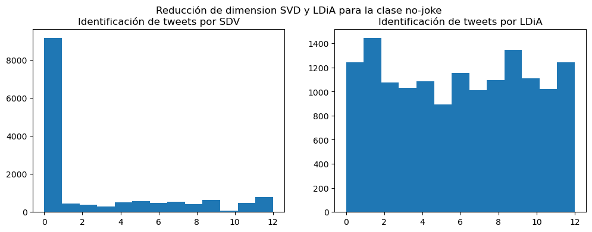

```python
fig, (ax1, ax2) = plt.subplots(1, 2)
fig.suptitle('Reducción de dimension SVD y LDiA para la clase no-joke \n')
fig.set_size_inches(12, 4)

nt = data.humor_mechanism.value_counts().value_counts().sum() + 1

#======================================= SDV
vectorizer = TfidfVectorizer(tokenizer = my_tokenizer).fit(X_no_joke)
vtfid = vectorizer.transform(raw_documents = X_no_joke)

svd = TruncatedSVD(n_components=nt, n_iter=100)
vectores_de_topicos_svd = svd.fit_transform(vtfid)
topicos=[f'tema{str(i+1).zfill(2)}' for i in range(nt)]
cols_num, terms_bow=zip(*sorted(zip(vectorizer.vocabulary_.values(), vectorizer.vocabulary_.keys())))

componentes_sdv=pd.DataFrame(svd.components_.T,columns=topicos,index=terms_bow)

tweet_topico = np.argmax(vectores_de_topicos_svd,axis=1)

ax1.hist(tweet_topico, bins=nt)
# ax1.set_xticks(ticks=range(len(top_words_bows)),labels = top_words_bows, rotation = 'vertical')
ax1.set_title('Identificación de tweets por SDV')


#======================================= LDiA
counter = CountVectorizer(tokenizer=my_tokenizer)
vsm = counter.fit_transform(raw_documents=X_no_joke)
cols_num,terms_bow=zip(*sorted(zip(counter.vocabulary_.values(), counter.vocabulary_.keys())))
tweets_bows=pd.DataFrame(vsm.toarray(),index=[f't{i}' for i in range(len(X_no_joke))], columns=terms_bow)

ldia = LDiA(n_components=nt)
vectores_de_topicos_ldia = ldia.fit_transform(tweets_bows)

#  Matrix palabra topico
topicos=[f'tema{str(i+1).zfill(2)}' for i in range(nt)]
componentes_ldia = pd.DataFrame(ldia.components_.T, index=terms_bow, columns=topicos)

tweet_temas=np.argmax(vectores_de_topicos_ldia,axis=1)
ax2.hist(tweet_temas, bins=nt)
# ax2.set_xticks(ticks=range(len(top_words_tf)),labels = top_words_tf, rotation = 'vertical')
ax2.set_title('Identificación de tweets por LDiA');
```

Al igual que con la clase `joke`, el método SDV concentra los tweets en el tema 1 mientras que LDiA hace una mejor distribución de estos.

#### Frecuencia de palabras por Tema

##### SDV

```python
tema1 = componentes_sdv.tema01.sort_values(ascending=False)[:10]
tema2 = componentes_sdv.tema02.sort_values(ascending=False)[:10]
tema3 = componentes_sdv.tema03.sort_values(ascending=False)[:10]
tema4 = componentes_sdv.tema04.sort_values(ascending=False)[:10]
tema5 = componentes_sdv.tema05.sort_values(ascending=False)[:10]
tema6 = componentes_sdv.tema06.sort_values(ascending=False)[:10]
tema7 = componentes_sdv.tema07.sort_values(ascending=False)[:10]
tema8 = componentes_sdv.tema08.sort_values(ascending=False)[:10]
tema9 = componentes_sdv.tema09.sort_values(ascending=False)[:10]
tema10 = componentes_sdv.tema10.sort_values(ascending=False)[:10]
tema11 = componentes_sdv.tema11.sort_values(ascending=False)[:10]
tema12 = componentes_sdv.tema12.sort_values(ascending=False)[:10]
tema13 = componentes_sdv.tema13.sort_values(ascending=False)[:10]

frecuancia_palabra_temas = pd.DataFrame(tema1).join(tema2, how='outer').join(tema3, how='outer').join(tema4, how='outer') \
                                                .join(tema5, how='outer').join(tema6, how='outer').join(tema7, how='outer') \
                                                .join(tema8, how='outer').join(tema9, how='outer').join(tema10, how='outer') \
                                                .join(tema11, how='outer').join(tema12, how='outer').join(tema13, how='outer')

frecuancia_palabra_temas
```

|  | tema01 | tema02 | tema03 | tema04 | tema05 | tema06 | tema07 | tema08 | tema09 | tema10 | tema11 | tema12 | tema13 |
| --- | --- | --- | --- | --- | --- | --- | --- | --- | --- | --- | --- | --- | --- |
| ahora | NaN | NaN | NaN | NaN | NaN | 0.101401 | NaN | NaN | NaN | NaN | NaN | NaN | 0.063805 |
| alguien | 0.133003 | NaN | NaN | NaN | NaN | NaN | NaN | 0.105590 | NaN | 0.247496 | NaN | NaN | NaN |
| algun | NaN | NaN | 0.029419 | NaN | NaN | NaN | NaN | NaN | NaN | NaN | NaN | NaN | NaN |
| amiga | NaN | NaN | NaN | NaN | NaN | NaN | NaN | NaN | 0.052593 | NaN | NaN | NaN | NaN |
| amigo | NaN | NaN | NaN | NaN | NaN | NaN | NaN | NaN | 0.090042 | NaN | NaN | NaN | NaN |
| amo | NaN | NaN | NaN | NaN | NaN | NaN | NaN | NaN | NaN | NaN | NaN | NaN | 0.118506 |
| amor | NaN | NaN | NaN | 0.049426 | NaN | NaN | 0.095582 | NaN | NaN | NaN | NaN | NaN | NaN |
| bien | 0.178164 | NaN | NaN | NaN | NaN | 0.094980 | NaN | 0.555583 | NaN | NaN | 0.290638 | 0.102491 | NaN |
| buen | NaN | NaN | 0.190755 | NaN | 0.062010 | NaN | 0.034321 | NaN | NaN | NaN | NaN | NaN | NaN |
| buenos | NaN | NaN | 0.241819 | 0.528395 | NaN | NaN | NaN | NaN | NaN | NaN | NaN | NaN | NaN |
| cine | NaN | 0.014150 | NaN | NaN | NaN | NaN | NaN | NaN | NaN | NaN | NaN | NaN | NaN |
| cosas | NaN | NaN | NaN | NaN | NaN | NaN | NaN | 0.061128 | NaN | NaN | NaN | NaN | NaN |
| d | NaN | NaN | NaN | 0.027647 | 0.122320 | NaN | NaN | NaN | NaN | NaN | NaN | NaN | NaN |
| dan | NaN | NaN | NaN | 0.024158 | NaN | NaN | NaN | NaN | NaN | 0.053222 | NaN | NaN | NaN |
| dia | 0.281809 | NaN | 0.588164 | NaN | 0.162029 | NaN | 0.078656 | NaN | NaN | NaN | NaN | NaN | NaN |
| dias | NaN | NaN | 0.287224 | 0.675697 | NaN | NaN | NaN | NaN | 0.037018 | NaN | NaN | NaN | NaN |
| dios | NaN | NaN | NaN | NaN | 0.033415 | NaN | NaN | NaN | NaN | NaN | NaN | NaN | NaN |
| dormir | NaN | NaN | NaN | NaN | NaN | 0.384397 | 0.092496 | NaN | NaN | NaN | 0.247075 | NaN | 0.309054 |
| dos | NaN | NaN | NaN | 0.038887 | NaN | NaN | NaN | NaN | NaN | NaN | NaN | NaN | NaN |
| feliz | NaN | NaN | 0.053069 | NaN | NaN | NaN | NaN | NaN | 0.044450 | NaN | NaN | 0.075283 | NaN |
| ganas | NaN | NaN | NaN | NaN | NaN | 0.147352 | NaN | NaN | NaN | 0.574783 | 0.303834 | NaN | NaN |
| gente | NaN | NaN | NaN | NaN | 0.027107 | NaN | NaN | 0.120176 | NaN | 0.066255 | 0.086468 | NaN | NaN |
| hace | NaN | NaN | NaN | NaN | NaN | NaN | NaN | 0.060423 | NaN | 0.069062 | NaN | NaN | 0.081055 |
| hacer | NaN | NaN | NaN | NaN | NaN | 0.114446 | NaN | NaN | NaN | NaN | NaN | NaN | NaN |
| helado | NaN | 0.021436 | NaN | NaN | NaN | NaN | NaN | NaN | NaN | NaN | NaN | NaN | NaN |
| hoy | 0.170463 | NaN | 0.211317 | NaN | 0.055818 | NaN | NaN | NaN | NaN | 0.202174 | 0.414332 | 0.653800 | 0.277759 |
| ir | NaN | 0.095673 | NaN | NaN | NaN | 0.082380 | NaN | NaN | NaN | 0.098665 | NaN | NaN | NaN |
| llorar | NaN | 0.021008 | NaN | NaN | NaN | NaN | NaN | NaN | NaN | NaN | NaN | NaN | NaN |
| mal | NaN | NaN | NaN | NaN | NaN | NaN | NaN | 0.210309 | NaN | NaN | 0.094729 | NaN | 0.164325 |
| matar | NaN | 0.021537 | NaN | NaN | NaN | NaN | NaN | NaN | NaN | NaN | NaN | NaN | NaN |
| mejor | 0.144503 | NaN | NaN | NaN | NaN | NaN | 0.091963 | 0.184642 | 0.861455 | NaN | 0.083046 | 0.048523 | NaN |
| mierda | NaN | NaN | 0.035839 | 0.046738 | NaN | NaN | NaN | NaN | NaN | NaN | NaN | NaN | NaN |
| morir | NaN | 0.024215 | NaN | NaN | NaN | NaN | NaN | NaN | NaN | NaN | NaN | NaN | NaN |
| mundo | NaN | NaN | NaN | NaN | NaN | NaN | NaN | NaN | 0.056770 | NaN | NaN | NaN | NaN |
| necesito | NaN | NaN | NaN | NaN | NaN | NaN | 0.032678 | NaN | NaN | NaN | NaN | NaN | NaN |
| nunca | NaN | NaN | NaN | NaN | NaN | 0.058045 | NaN | NaN | NaN | 0.171758 | NaN | 0.178374 | NaN |
| pa | NaN | NaN | NaN | NaN | 0.024020 | NaN | NaN | NaN | NaN | NaN | NaN | NaN | NaN |
| pq | NaN | NaN | NaN | NaN | 0.022084 | NaN | NaN | NaN | NaN | NaN | NaN | NaN | NaN |
| puedo | NaN | NaN | NaN | NaN | NaN | NaN | NaN | NaN | 0.056666 | NaN | 0.130111 | NaN | 0.190653 |
| q | 0.198176 | NaN | NaN | 0.117529 | 0.813708 | NaN | 0.134463 | NaN | 0.039639 | NaN | NaN | 0.052800 | NaN |
| quiero | 0.386826 | 0.840318 | 0.272315 | NaN | 0.068508 | NaN | NaN | NaN | NaN | NaN | NaN | 0.042660 | NaN |
| ser | 0.204799 | NaN | NaN | NaN | NaN | NaN | NaN | NaN | 0.044959 | NaN | NaN | NaN | NaN |
| siempre | NaN | NaN | NaN | NaN | NaN | NaN | NaN | 0.206579 | NaN | 0.253653 | NaN | 0.114072 | 0.532654 |
| siento | NaN | NaN | NaN | NaN | NaN | NaN | NaN | 0.069982 | NaN | NaN | 0.084348 | NaN | 0.078204 |
| solo | NaN | NaN | NaN | 0.027765 | NaN | NaN | NaN | 0.070741 | NaN | 0.056566 | NaN | NaN | NaN |
| sueno | NaN | NaN | NaN | NaN | NaN | 0.062772 | 0.059194 | NaN | NaN | NaN | NaN | NaN | 0.179716 |
| tan | NaN | NaN | NaN | NaN | NaN | NaN | NaN | NaN | NaN | NaN | 0.088928 | NaN | NaN |
| temprano | NaN | NaN | 0.020972 | NaN | NaN | NaN | NaN | NaN | NaN | NaN | NaN | NaN | NaN |
| toda | NaN | NaN | NaN | NaN | NaN | NaN | 0.043312 | NaN | NaN | NaN | NaN | NaN | NaN |
| veces | NaN | NaN | NaN | NaN | NaN | NaN | NaN | NaN | 0.060468 | NaN | NaN | NaN | NaN |
| ver | NaN | 0.039716 | NaN | NaN | NaN | 0.060640 | NaN | NaN | NaN | NaN | NaN | NaN | NaN |
| vida | 0.199725 | NaN | NaN | 0.046962 | NaN | NaN | 0.671159 | NaN | NaN | NaN | NaN | 0.097027 | NaN |
| volver | NaN | 0.021154 | NaN | NaN | NaN | NaN | NaN | NaN | NaN | NaN | NaN | NaN | NaN |
| vos | NaN | 0.018653 | NaN | NaN | NaN | NaN | NaN | NaN | NaN | NaN | NaN | NaN | NaN |
| voy | 0.172623 | NaN | NaN | NaN | NaN | 0.575389 | NaN | NaN | NaN | NaN | NaN | 0.263546 | NaN |

##### LDiA

```python
tema1 = componentes_ldia.tema01.sort_values(ascending=False)[:10]
tema2 = componentes_ldia.tema02.sort_values(ascending=False)[:10]
tema3 = componentes_ldia.tema03.sort_values(ascending=False)[:10]
tema4 = componentes_ldia.tema04.sort_values(ascending=False)[:10]
tema5 = componentes_ldia.tema05.sort_values(ascending=False)[:10]
tema6 = componentes_ldia.tema06.sort_values(ascending=False)[:10]
tema7 = componentes_ldia.tema07.sort_values(ascending=False)[:10]
tema8 = componentes_ldia.tema08.sort_values(ascending=False)[:10]
tema9 = componentes_ldia.tema09.sort_values(ascending=False)[:10]
tema10 = componentes_ldia.tema10.sort_values(ascending=False)[:10]
tema11 = componentes_ldia.tema11.sort_values(ascending=False)[:10]
tema12 = componentes_ldia.tema12.sort_values(ascending=False)[:10]
tema13 = componentes_ldia.tema13.sort_values(ascending=False)[:10]

frecuancia_palabra_temas = pd.DataFrame(tema1).join(tema2, how='outer').join(tema3, how='outer').join(tema4, how='outer') \
                                                .join(tema5, how='outer').join(tema6, how='outer').join(tema7, how='outer') \
                                                .join(tema8, how='outer').join(tema9, how='outer').join(tema10, how='outer') \
                                                .join(tema11, how='outer').join(tema12, how='outer').join(tema13, how='outer')

frecuancia_palabra_temas.head(60)
```

|  | tema01 | tema02 | tema03 | tema04 | tema05 | tema06 | tema07 | tema08 | tema09 | tema10 | tema11 | tema12 | tema13 |
| --- | --- | --- | --- | --- | --- | --- | --- | --- | --- | --- | --- | --- | --- |
| 1 | NaN | NaN | NaN | NaN | NaN | NaN | NaN | 67.228850 | NaN | NaN | NaN | NaN | NaN |
| 2 | NaN | NaN | NaN | NaN | NaN | NaN | NaN | 111.310260 | NaN | NaN | NaN | NaN | NaN |
| 3 | NaN | NaN | NaN | NaN | NaN | NaN | NaN | 98.264487 | NaN | NaN | NaN | NaN | NaN |
| 4 | NaN | NaN | NaN | NaN | NaN | NaN | NaN | 32.105920 | NaN | NaN | NaN | NaN | NaN |
| 5 | NaN | NaN | NaN | NaN | NaN | NaN | NaN | 36.641583 | NaN | NaN | NaN | NaN | NaN |
| ahora | NaN | NaN | NaN | NaN | NaN | NaN | NaN | NaN | NaN | 147.926400 | NaN | NaN | NaN |
| alguien | NaN | NaN | NaN | NaN | NaN | NaN | 64.808644 | NaN | NaN | NaN | 57.097514 | NaN | NaN |
| amigo | NaN | NaN | NaN | NaN | 33.690256 | NaN | NaN | NaN | NaN | NaN | NaN | NaN | NaN |
| amigos | NaN | NaN | NaN | NaN | NaN | NaN | NaN | NaN | NaN | NaN | NaN | 38.334979 | NaN |
| amo | NaN | NaN | NaN | NaN | NaN | 66.778262 | NaN | NaN | NaN | NaN | NaN | NaN | NaN |
| amor | NaN | NaN | NaN | NaN | NaN | NaN | NaN | NaN | 153.220821 | NaN | NaN | NaN | NaN |
| anos | NaN | NaN | NaN | NaN | NaN | NaN | NaN | 43.505759 | NaN | NaN | NaN | NaN | NaN |
| asi | NaN | NaN | NaN | NaN | NaN | NaN | NaN | NaN | NaN | 72.491766 | NaN | NaN | NaN |
| bien | NaN | 119.109759 | NaN | 63.509481 | NaN | NaN | NaN | NaN | 36.413562 | NaN | NaN | NaN | 50.241409 |
| buen | NaN | NaN | NaN | NaN | NaN | NaN | NaN | NaN | NaN | 76.123321 | NaN | NaN | NaN |
| buenas | NaN | NaN | NaN | NaN | NaN | NaN | NaN | NaN | NaN | NaN | 50.112150 | NaN | NaN |
| bueno | NaN | NaN | NaN | NaN | NaN | NaN | NaN | NaN | NaN | NaN | NaN | 26.693896 | NaN |
| buenos | NaN | NaN | NaN | NaN | NaN | NaN | NaN | NaN | NaN | NaN | 129.767755 | NaN | NaN |
| casa | 78.287623 | NaN | NaN | NaN | NaN | NaN | NaN | NaN | NaN | NaN | NaN | NaN | NaN |
| corazon | NaN | NaN | NaN | NaN | NaN | NaN | NaN | NaN | NaN | NaN | NaN | NaN | 49.262575 |
| cosas | NaN | NaN | NaN | NaN | NaN | NaN | NaN | 43.866460 | NaN | NaN | NaN | NaN | NaN |
| cuenta | NaN | NaN | NaN | NaN | 76.020399 | NaN | NaN | NaN | NaN | NaN | NaN | 28.190036 | NaN |
| d | 122.089716 | NaN | NaN | NaN | NaN | NaN | NaN | NaN | NaN | NaN | NaN | NaN | NaN |
| da | 46.451994 | NaN | 38.818926 | NaN | NaN | NaN | NaN | NaN | NaN | NaN | NaN | NaN | NaN |
| decir | NaN | NaN | NaN | NaN | NaN | NaN | NaN | NaN | NaN | NaN | NaN | 54.075657 | NaN |
| dia | NaN | NaN | NaN | NaN | NaN | 32.283898 | NaN | 39.097357 | NaN | 192.876857 | NaN | 35.818797 | NaN |
| dias | NaN | NaN | NaN | NaN | NaN | NaN | NaN | NaN | NaN | NaN | 229.411540 | NaN | NaN |
| dios | NaN | NaN | NaN | NaN | NaN | NaN | NaN | NaN | 34.485778 | NaN | NaN | NaN | NaN |
| dormir | NaN | 130.300676 | NaN | NaN | NaN | NaN | NaN | NaN | NaN | NaN | NaN | NaN | NaN |
| extrano | NaN | NaN | NaN | 62.645430 | NaN | NaN | NaN | NaN | NaN | NaN | NaN | NaN | NaN |
| feliz | 72.041995 | NaN | NaN | NaN | NaN | NaN | NaN | NaN | NaN | 54.659812 | NaN | NaN | NaN |
| ganas | NaN | NaN | NaN | NaN | NaN | NaN | 66.241730 | NaN | NaN | NaN | NaN | NaN | NaN |
| gente | NaN | NaN | NaN | NaN | 77.331557 | NaN | NaN | NaN | NaN | 46.471787 | NaN | NaN | 60.552565 |
| guau | NaN | NaN | NaN | NaN | NaN | NaN | 65.248720 | NaN | NaN | NaN | NaN | NaN | NaN |
| hablar | NaN | NaN | NaN | 40.018952 | NaN | NaN | NaN | NaN | NaN | NaN | NaN | NaN | NaN |
| hace | NaN | NaN | NaN | 49.002443 | NaN | NaN | NaN | NaN | 49.918717 | NaN | NaN | NaN | NaN |
| hacer | NaN | 105.810376 | NaN | NaN | 48.689020 | NaN | NaN | NaN | NaN | NaN | NaN | NaN | NaN |
| hora | NaN | NaN | NaN | NaN | NaN | NaN | NaN | NaN | NaN | NaN | NaN | 60.292645 | NaN |
| hoy | NaN | NaN | 38.302332 | NaN | 38.463675 | NaN | NaN | 51.717464 | NaN | NaN | NaN | 47.416380 | NaN |
| lunes | NaN | NaN | NaN | NaN | NaN | NaN | 45.572603 | NaN | NaN | NaN | NaN | NaN | NaN |
| madre | NaN | NaN | NaN | 63.702162 | NaN | NaN | NaN | NaN | NaN | NaN | NaN | NaN | NaN |
| madrid | NaN | NaN | NaN | NaN | NaN | 30.892686 | NaN | NaN | NaN | NaN | NaN | NaN | NaN |
| mal | NaN | NaN | NaN | NaN | NaN | NaN | 155.255202 | NaN | NaN | NaN | NaN | NaN | NaN |
| mama | NaN | NaN | NaN | NaN | 32.263995 | NaN | NaN | NaN | NaN | NaN | NaN | NaN | NaN |
| manana | NaN | NaN | NaN | NaN | NaN | NaN | NaN | NaN | NaN | NaN | 48.238683 | NaN | NaN |
| mejor | 43.478061 | 57.234785 | 64.153984 | NaN | NaN | NaN | NaN | NaN | 32.056880 | NaN | NaN | NaN | NaN |
| menos | NaN | NaN | NaN | NaN | NaN | NaN | NaN | NaN | 34.464499 | NaN | NaN | NaN | NaN |
| mundo | NaN | NaN | NaN | NaN | 31.224657 | NaN | NaN | NaN | 34.605847 | NaN | NaN | NaN | NaN |
| nadie | NaN | NaN | NaN | NaN | NaN | 47.369045 | NaN | NaN | NaN | NaN | NaN | NaN | 58.930285 |
| noche | NaN | NaN | NaN | NaN | 62.795623 | NaN | NaN | NaN | NaN | NaN | NaN | NaN | NaN |
| noches | NaN | NaN | NaN | NaN | NaN | NaN | NaN | NaN | NaN | NaN | 49.598686 | NaN | NaN |
| novia | NaN | NaN | 38.572941 | NaN | NaN | NaN | NaN | NaN | NaN | NaN | NaN | NaN | NaN |
| nunca | 43.637387 | NaN | NaN | 43.024610 | NaN | NaN | NaN | NaN | NaN | NaN | NaN | NaN | 61.199906 |
| odio | NaN | NaN | NaN | NaN | NaN | 36.054852 | NaN | NaN | NaN | NaN | NaN | NaN | NaN |
| persona | NaN | NaN | NaN | NaN | NaN | NaN | NaN | NaN | 30.103341 | NaN | NaN | NaN | NaN |
| personas | NaN | NaN | 35.039859 | NaN | NaN | NaN | 40.994608 | NaN | NaN | NaN | NaN | NaN | NaN |
| puedo | NaN | 95.072874 | NaN | NaN | NaN | NaN | NaN | NaN | NaN | NaN | NaN | NaN | NaN |
| puta | NaN | NaN | NaN | 149.662247 | NaN | NaN | NaN | NaN | NaN | NaN | NaN | NaN | NaN |
| q | 366.316166 | 69.940968 | NaN | NaN | NaN | NaN | NaN | NaN | NaN | NaN | NaN | NaN | NaN |
| quieren | NaN | NaN | 33.591970 | NaN | NaN | NaN | NaN | NaN | NaN | NaN | NaN | NaN | NaN |

```python
frecuancia_palabra_temas.tail(17)
```

|  | tema01 | tema02 | tema03 | tema04 | tema05 | tema06 | tema07 | tema08 | tema09 | tema10 | tema11 | tema12 | tema13 |
| --- | --- | --- | --- | --- | --- | --- | --- | --- | --- | --- | --- | --- | --- |
| semana | 50.912868 | NaN | NaN | NaN | NaN | NaN | NaN | NaN | NaN | NaN | NaN | NaN | NaN |
| ser | NaN | NaN | 57.082889 | NaN | 31.315144 | 32.344404 | 44.116730 | NaN | 44.839122 | NaN | 46.411361 | NaN | 52.380483 |
| siempre | NaN | NaN | NaN | 39.723077 | NaN | NaN | NaN | NaN | NaN | NaN | 71.803625 | NaN | NaN |
| sigue | NaN | NaN | NaN | NaN | NaN | NaN | NaN | NaN | NaN | NaN | NaN | 39.716403 | NaN |
| solo | NaN | NaN | NaN | 41.438792 | NaN | NaN | 50.867378 | NaN | 61.916901 | NaN | NaN | 33.323761 | NaN |
| sueno | NaN | NaN | 77.700957 | NaN | NaN | NaN | NaN | NaN | NaN | NaN | NaN | NaN | NaN |
| tan | NaN | NaN | NaN | NaN | NaN | 30.154860 | NaN | NaN | NaN | NaN | NaN | NaN | 64.834283 |
| tarde | NaN | 66.071567 | NaN | NaN | NaN | NaN | NaN | NaN | NaN | NaN | NaN | NaN | NaN |
| tipico | 47.752822 | NaN | NaN | NaN | NaN | NaN | NaN | NaN | NaN | NaN | NaN | NaN | NaN |
| va | NaN | 69.354445 | 37.170267 | NaN | NaN | NaN | NaN | NaN | NaN | NaN | NaN | NaN | NaN |
| vamos | NaN | NaN | NaN | NaN | NaN | NaN | NaN | NaN | NaN | 42.749884 | NaN | NaN | NaN |
| veces | NaN | NaN | NaN | NaN | 50.310612 | NaN | NaN | NaN | NaN | NaN | NaN | NaN | NaN |
| ver | NaN | NaN | NaN | 52.760337 | NaN | NaN | NaN | NaN | NaN | 79.828010 | NaN | NaN | 44.581379 |
| vida | 51.646134 | 70.220795 | 49.984146 | NaN | NaN | 62.726842 | 40.988101 | NaN | NaN | 46.750191 | NaN | NaN | 64.977258 |
| vivir | NaN | NaN | NaN | NaN | NaN | 31.108655 | NaN | NaN | NaN | NaN | NaN | NaN | NaN |
| vos | NaN | NaN | NaN | NaN | NaN | NaN | 40.238775 | NaN | NaN | NaN | NaN | NaN | NaN |
| voy | NaN | NaN | NaN | NaN | NaN | NaN | NaN | NaN | NaN | 56.811163 | 101.406724 | NaN | NaN |

### Mecanismo de humor

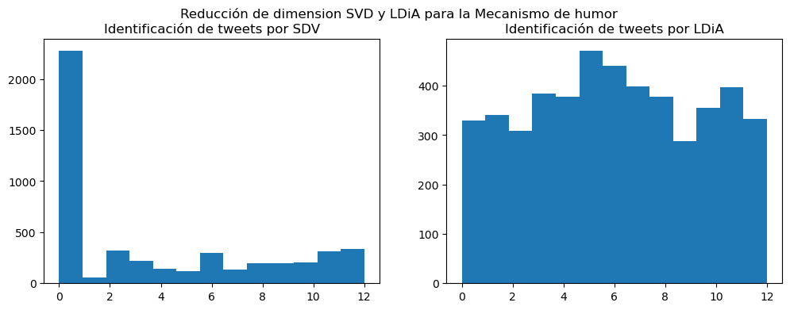

```python
fig, (ax1, ax2) = plt.subplots(1, 2)
fig.suptitle('Reducción de dimension SVD y LDiA para la Mecanismo de humor \n')
fig.set_size_inches(12, 4)

nt = data.humor_mechanism.value_counts().value_counts().sum() + 1

#======================================= SDV
vectorizer = TfidfVectorizer(tokenizer = my_tokenizer).fit(X_mechanism)
vtfid = vectorizer.transform(raw_documents = X_mechanism)

svd = TruncatedSVD(n_components=nt, n_iter=100)
vectores_de_topicos_svd = svd.fit_transform(vtfid)
topicos=[f'tema{str(i+1).zfill(2)}' for i in range(nt)]
cols_num, terms_bow=zip(*sorted(zip(vectorizer.vocabulary_.values(), vectorizer.vocabulary_.keys())))

componentes_sdv=pd.DataFrame(svd.components_.T,columns=topicos,index=terms_bow)

tweet_topico = np.argmax(vectores_de_topicos_svd,axis=1)

ax1.hist(tweet_topico, bins=nt)
# ax1.set_xticks(ticks=range(len(top_words_bows)),labels = top_words_bows, rotation = 'vertical')
ax1.set_title('Identificación de tweets por SDV')


#======================================= LDiA
counter = CountVectorizer(tokenizer=my_tokenizer)
vsm = counter.fit_transform(raw_documents=X_mechanism)
cols_num,terms_bow=zip(*sorted(zip(counter.vocabulary_.values(), counter.vocabulary_.keys())))
tweets_bows=pd.DataFrame(vsm.toarray(),index=[f't{i}' for i in range(len(X_mechanism))], columns=terms_bow)

ldia = LDiA(n_components=nt)
vectores_de_topicos_ldia = ldia.fit_transform(tweets_bows)

#  Matrix palabra topico
topicos=[f'tema{str(i+1).zfill(2)}' for i in range(nt)]
componentes_ldia = pd.DataFrame(ldia.components_.T, index=terms_bow, columns=topicos)

tweet_temas=np.argmax(vectores_de_topicos_ldia,axis=1)
ax2.hist(tweet_temas, bins=nt)
# ax2.set_xticks(ticks=range(len(top_words_tf)),labels = top_words_tf, rotation = 'vertical')
ax2.set_title('Identificación de tweets por LDiA');
```

El caso se repite para todas las clases y para Mecanismo de humor.

#### Frecuencia de palabras por Tema

##### SDV

```python
tema1 = componentes_sdv.tema01.sort_values(ascending=False)[:10]
tema2 = componentes_sdv.tema02.sort_values(ascending=False)[:10]
tema3 = componentes_sdv.tema03.sort_values(ascending=False)[:10]
tema4 = componentes_sdv.tema04.sort_values(ascending=False)[:10]
tema5 = componentes_sdv.tema05.sort_values(ascending=False)[:10]
tema6 = componentes_sdv.tema06.sort_values(ascending=False)[:10]
tema7 = componentes_sdv.tema07.sort_values(ascending=False)[:10]
tema8 = componentes_sdv.tema08.sort_values(ascending=False)[:10]
tema9 = componentes_sdv.tema09.sort_values(ascending=False)[:10]
tema10 = componentes_sdv.tema10.sort_values(ascending=False)[:10]
tema11 = componentes_sdv.tema11.sort_values(ascending=False)[:10]
tema12 = componentes_sdv.tema12.sort_values(ascending=False)[:10]
tema13 = componentes_sdv.tema13.sort_values(ascending=False)[:10]

frecuancia_palabra_temas = pd.DataFrame(tema1).join(tema2, how='outer').join(tema3, how='outer').join(tema4, how='outer') \
                                                .join(tema5, how='outer').join(tema6, how='outer').join(tema7, how='outer') \
                                                .join(tema8, how='outer').join(tema9, how='outer').join(tema10, how='outer') \
                                                .join(tema11, how='outer').join(tema12, how='outer').join(tema13, how='outer')

frecuancia_palabra_temas.head(60)
```

|  | tema01 | tema02 | tema03 | tema04 | tema05 | tema06 | tema07 | tema08 | tema09 | tema10 | tema11 | tema12 | tema13 |
| --- | --- | --- | --- | --- | --- | --- | --- | --- | --- | --- | --- | --- | --- |
| 1 | NaN | NaN | NaN | NaN | NaN | NaN | NaN | 0.165124 | NaN | NaN | 0.084112 | NaN | NaN |
| 2 | NaN | NaN | NaN | NaN | NaN | NaN | NaN | 0.235963 | NaN | NaN | NaN | NaN | NaN |
| 3 | NaN | NaN | NaN | NaN | NaN | NaN | NaN | 0.195869 | NaN | NaN | 0.079619 | NaN | NaN |
| 4 | NaN | NaN | NaN | NaN | NaN | NaN | NaN | 0.097216 | NaN | NaN | NaN | NaN | NaN |
| 5 | NaN | NaN | NaN | NaN | NaN | NaN | NaN | 0.091617 | NaN | NaN | NaN | NaN | NaN |
| adoptado | NaN | 0.023767 | NaN | NaN | NaN | NaN | NaN | NaN | NaN | NaN | NaN | NaN | NaN |
| ah | NaN | NaN | NaN | NaN | NaN | 0.057770 | NaN | NaN | NaN | NaN | NaN | NaN | NaN |
| alguien | NaN | NaN | NaN | NaN | NaN | NaN | 0.055589 | NaN | NaN | NaN | NaN | NaN | NaN |
| amor | 0.173775 | NaN | NaN | 0.692273 | NaN | NaN | NaN | 0.292831 | NaN | NaN | 0.198333 | NaN | NaN |
| anecdotas | NaN | NaN | 0.074575 | NaN | NaN | NaN | NaN | NaN | NaN | NaN | NaN | NaN | NaN |
| bien | NaN | NaN | NaN | NaN | NaN | NaN | NaN | NaN | NaN | NaN | NaN | NaN | 0.286271 |
| borracho | NaN | NaN | NaN | NaN | NaN | NaN | 0.049840 | NaN | NaN | NaN | NaN | NaN | NaN |
| callate | NaN | 0.019968 | NaN | NaN | NaN | NaN | NaN | NaN | NaN | NaN | NaN | NaN | NaN |
| chiste | 0.145856 | NaN | 0.302349 | 0.089044 | NaN | NaN | NaN | NaN | 0.184017 | 0.146844 | NaN | NaN | NaN |
| chistes | 0.246484 | NaN | 0.680507 | NaN | NaN | 0.069170 | NaN | NaN | NaN | NaN | 0.135395 | NaN | NaN |
| colegio | NaN | 0.073531 | NaN | NaN | NaN | NaN | NaN | NaN | NaN | NaN | NaN | NaN | NaN |
| dia | NaN | NaN | NaN | NaN | NaN | NaN | NaN | NaN | NaN | NaN | NaN | 0.100372 | NaN |
| dice | 0.157568 | NaN | NaN | NaN | NaN | NaN | 0.698824 | 0.220096 | 0.337585 | NaN | 0.228363 | NaN | NaN |
| dicen | 0.127531 | 0.142972 | NaN | NaN | NaN | NaN | NaN | NaN | NaN | NaN | NaN | NaN | NaN |
| dijo | NaN | NaN | 0.053465 | NaN | NaN | NaN | NaN | NaN | NaN | NaN | NaN | NaN | NaN |
| dime | NaN | NaN | NaN | 0.062372 | NaN | NaN | NaN | NaN | NaN | NaN | NaN | NaN | NaN |
| doctor | NaN | NaN | 0.037174 | NaN | NaN | NaN | NaN | NaN | NaN | NaN | NaN | NaN | NaN |
| dormir | NaN | NaN | NaN | NaN | NaN | NaN | NaN | NaN | NaN | NaN | NaN | 0.119227 | NaN |
| escuela | NaN | 0.108342 | NaN | NaN | NaN | NaN | NaN | NaN | NaN | NaN | NaN | NaN | NaN |
| fb | NaN | NaN | NaN | NaN | 0.103130 | NaN | 0.239961 | NaN | NaN | 0.234089 | NaN | NaN | NaN |
| fea | NaN | NaN | NaN | NaN | 0.146818 | NaN | NaN | NaN | NaN | NaN | NaN | NaN | NaN |
| feo | NaN | NaN | NaN | NaN | 0.111349 | NaN | NaN | NaN | NaN | NaN | NaN | NaN | NaN |
| frases | NaN | NaN | 0.042896 | NaN | NaN | NaN | NaN | NaN | NaN | NaN | NaN | NaN | NaN |
| gorda | NaN | NaN | NaN | 0.087038 | NaN | NaN | NaN | NaN | NaN | NaN | NaN | NaN | NaN |
| hace | NaN | NaN | NaN | 0.053291 | NaN | NaN | NaN | NaN | NaN | NaN | NaN | NaN | NaN |
| hacer | NaN | NaN | NaN | NaN | NaN | NaN | NaN | NaN | NaN | NaN | NaN | 0.145775 | NaN |
| hijo | 0.168394 | 0.080028 | NaN | NaN | 0.092985 | 0.238163 | NaN | 0.215270 | NaN | NaN | NaN | NaN | NaN |
| hola | NaN | NaN | 0.032305 | NaN | NaN | NaN | NaN | NaN | NaN | NaN | NaN | NaN | NaN |
| hombre | NaN | NaN | NaN | NaN | 0.081187 | NaN | 0.128919 | NaN | NaN | 0.317722 | NaN | 0.127563 | 0.170123 |
| hombres | NaN | NaN | NaN | NaN | NaN | NaN | NaN | NaN | NaN | NaN | NaN | NaN | 0.113372 |
| humor | NaN | NaN | 0.248927 | NaN | NaN | 0.062308 | NaN | NaN | NaN | NaN | 0.134877 | NaN | 0.092305 |
| jajaja | NaN | NaN | NaN | 0.059690 | NaN | NaN | NaN | NaN | 0.234880 | NaN | NaN | NaN | NaN |
| llaman | NaN | 0.026927 | NaN | NaN | NaN | NaN | NaN | NaN | NaN | NaN | NaN | NaN | NaN |
| llega | NaN | NaN | NaN | NaN | NaN | NaN | 0.054937 | NaN | NaN | NaN | NaN | NaN | NaN |
| madre | NaN | NaN | NaN | NaN | NaN | NaN | NaN | NaN | NaN | NaN | 0.095419 | NaN | NaN |
| mama | 0.560365 | 0.692449 | NaN | 0.055682 | NaN | NaN | NaN | NaN | NaN | NaN | NaN | NaN | NaN |
| mejor | NaN | NaN | NaN | NaN | 0.071589 | NaN | NaN | NaN | NaN | 0.134048 | NaN | 0.137516 | 0.145668 |
| mujer | NaN | NaN | NaN | NaN | 0.088266 | NaN | 0.227096 | NaN | NaN | 0.408981 | NaN | 0.186354 | 0.306542 |
| mujeres | NaN | NaN | NaN | NaN | NaN | NaN | NaN | NaN | NaN | NaN | NaN | NaN | 0.159404 |
| novia | NaN | NaN | NaN | NaN | NaN | NaN | 0.078190 | NaN | 0.063637 | NaN | NaN | NaN | 0.109674 |
| oye | NaN | NaN | NaN | NaN | NaN | NaN | NaN | NaN | 0.101523 | NaN | NaN | NaN | NaN |
| papa | 0.152619 | 0.023052 | NaN | NaN | 0.094224 | 0.649439 | NaN | 0.389772 | NaN | 0.112823 | NaN | NaN | NaN |
| preguntale | NaN | 0.021886 | NaN | NaN | NaN | NaN | NaN | NaN | NaN | NaN | NaN | NaN | NaN |
| pues | NaN | NaN | NaN | NaN | NaN | 0.080629 | NaN | NaN | NaN | NaN | NaN | NaN | NaN |
| quieres | NaN | NaN | NaN | NaN | NaN | NaN | NaN | NaN | NaN | NaN | 0.106104 | NaN | NaN |
| quiero | NaN | NaN | NaN | NaN | NaN | 0.100591 | NaN | NaN | 0.097065 | 0.180870 | 0.422503 | NaN | NaN |
| rt | 0.186752 | NaN | 0.297057 | 0.148577 | NaN | NaN | NaN | NaN | 0.356357 | 0.205232 | NaN | NaN | NaN |
| senora | NaN | NaN | NaN | NaN | NaN | NaN | 0.049964 | NaN | NaN | NaN | NaN | NaN | NaN |
| ser | NaN | NaN | NaN | NaN | 0.071984 | 0.094855 | NaN | NaN | 0.104655 | 0.275346 | 0.414250 | 0.204970 | NaN |
| siempre | NaN | NaN | NaN | NaN | NaN | NaN | 0.064720 | NaN | NaN | NaN | NaN | NaN | 0.180914 |
| solo | NaN | NaN | NaN | NaN | NaN | NaN | NaN | NaN | NaN | NaN | NaN | NaN | 0.218093 |
| tan | NaN | NaN | 0.114025 | NaN | 0.610037 | NaN | NaN | 0.221083 | 0.087665 | NaN | NaN | 0.094226 | NaN |
| tener | NaN | NaN | NaN | NaN | NaN | 0.053660 | NaN | NaN | NaN | NaN | NaN | NaN | NaN |
| vida | NaN | NaN | NaN | 0.130439 | NaN | NaN | NaN | NaN | NaN | NaN | NaN | 0.369413 | NaN |
| voy | NaN | NaN | NaN | NaN | NaN | 0.075324 | NaN | NaN | NaN | NaN | NaN | 0.156669 | NaN |

```python
frecuancia_palabra_temas.tail(1)
```

|  | tema01 | tema02 | tema03 | tema04 | tema05 | tema06 | tema07 | tema08 | tema09 | tema10 | tema11 | tema12 | tema13 |
| --- | --- | --- | --- | --- | --- | --- | --- | --- | --- | --- | --- | --- | --- |
| xd | 0.107521 | NaN | NaN | 0.119035 | NaN | NaN | NaN | NaN | 0.314251 | 0.145258 | NaN | NaN | NaN |

##### LDiA

```python
tema1 = componentes_ldia.tema01.sort_values(ascending=False)[:10]
tema2 = componentes_ldia.tema02.sort_values(ascending=False)[:10]
tema3 = componentes_ldia.tema03.sort_values(ascending=False)[:10]
tema4 = componentes_ldia.tema04.sort_values(ascending=False)[:10]
tema5 = componentes_ldia.tema05.sort_values(ascending=False)[:10]
tema6 = componentes_ldia.tema06.sort_values(ascending=False)[:10]
tema7 = componentes_ldia.tema07.sort_values(ascending=False)[:10]
tema8 = componentes_ldia.tema08.sort_values(ascending=False)[:10]
tema9 = componentes_ldia.tema09.sort_values(ascending=False)[:10]
tema10 = componentes_ldia.tema10.sort_values(ascending=False)[:10]
tema11 = componentes_ldia.tema11.sort_values(ascending=False)[:10]
tema12 = componentes_ldia.tema12.sort_values(ascending=False)[:10]
tema13 = componentes_ldia.tema13.sort_values(ascending=False)[:10]

frecuancia_palabra_temas = pd.DataFrame(tema1).join(tema2, how='outer').join(tema3, how='outer').join(tema4, how='outer') \
                                                .join(tema5, how='outer').join(tema6, how='outer').join(tema7, how='outer') \
                                                .join(tema8, how='outer').join(tema9, how='outer').join(tema10, how='outer') \
                                                .join(tema11, how='outer').join(tema12, how='outer').join(tema13, how='outer')

frecuancia_palabra_temas.head(60)
```

|  | tema01 | tema02 | tema03 | tema04 | tema05 | tema06 | tema07 | tema08 | tema09 | tema10 | tema11 | tema12 | tema13 |
| --- | --- | --- | --- | --- | --- | --- | --- | --- | --- | --- | --- | --- | --- |
| 1 | NaN | 15.324808 | NaN | NaN | NaN | 32.249244 | NaN | NaN | NaN | NaN | NaN | NaN | NaN |
| 10 | NaN | NaN | NaN | NaN | NaN | NaN | NaN | 24.449235 | NaN | NaN | NaN | NaN | NaN |
| 2 | NaN | NaN | NaN | NaN | NaN | 61.516072 | NaN | NaN | NaN | NaN | NaN | NaN | NaN |
| 3 | NaN | NaN | NaN | NaN | NaN | 77.075443 | NaN | NaN | NaN | NaN | NaN | NaN | NaN |
| ah | NaN | NaN | NaN | NaN | NaN | NaN | NaN | NaN | NaN | NaN | NaN | NaN | 17.815421 |
| ahora | NaN | NaN | NaN | NaN | NaN | NaN | NaN | NaN | NaN | 12.076944 | NaN | NaN | NaN |
| amor | NaN | NaN | 18.358396 | 40.146479 | NaN | 37.925222 | 27.835233 | 20.288154 | 16.048994 | NaN | 28.273237 | 57.619830 | NaN |
| ano | NaN | NaN | NaN | NaN | NaN | NaN | NaN | NaN | 17.763435 | NaN | NaN | NaN | NaN |
| anos | NaN | 19.246276 | 35.952572 | NaN | NaN | NaN | NaN | NaN | NaN | NaN | NaN | NaN | NaN |
| asi | NaN | NaN | NaN | NaN | NaN | NaN | NaN | NaN | NaN | 11.879021 | NaN | NaN | NaN |
| bien | NaN | NaN | NaN | NaN | 17.262226 | NaN | 28.902488 | NaN | NaN | NaN | NaN | NaN | NaN |
| bueno | NaN | 27.819242 | NaN | NaN | NaN | NaN | NaN | NaN | NaN | NaN | NaN | NaN | NaN |
| cama | NaN | NaN | NaN | NaN | NaN | NaN | NaN | NaN | 16.653224 | NaN | NaN | NaN | NaN |
| casa | NaN | NaN | NaN | NaN | NaN | NaN | NaN | NaN | 20.646257 | NaN | NaN | NaN | NaN |
| chiste | NaN | 17.654707 | NaN | NaN | NaN | NaN | NaN | NaN | NaN | NaN | 27.482628 | NaN | 22.288991 |
| chistes | 24.522337 | 36.179738 | 38.584038 | 16.157237 | 31.260310 | 27.683250 | NaN | 18.939406 | 17.390422 | 19.237806 | 44.710583 | 20.161846 | 51.357952 |
| comer | NaN | NaN | NaN | 15.975537 | NaN | NaN | NaN | NaN | NaN | NaN | NaN | NaN | NaN |
| dia | NaN | NaN | NaN | NaN | NaN | NaN | 27.998306 | NaN | NaN | NaN | NaN | NaN | NaN |
| dice | NaN | NaN | NaN | 27.548511 | 26.010856 | 43.053822 | NaN | NaN | 22.293153 | NaN | 32.151043 | NaN | 17.712602 |
| dicen | NaN | NaN | NaN | NaN | NaN | NaN | NaN | NaN | NaN | NaN | 53.611649 | NaN | NaN |
| dijo | 17.041904 | NaN | NaN | NaN | NaN | NaN | NaN | NaN | NaN | NaN | NaN | NaN | NaN |
| doctor | NaN | NaN | NaN | NaN | 17.803170 | NaN | 27.119610 | NaN | NaN | NaN | NaN | NaN | NaN |
| dormir | NaN | NaN | NaN | NaN | NaN | NaN | NaN | NaN | NaN | 15.630887 | NaN | NaN | NaN |
| dos | NaN | 15.841802 | NaN | 18.091184 | 16.471590 | NaN | NaN | NaN | NaN | NaN | NaN | NaN | NaN |
| escribiendo | NaN | NaN | NaN | NaN | NaN | NaN | 21.076922 | NaN | NaN | NaN | NaN | NaN | NaN |
| escuela | NaN | NaN | NaN | NaN | NaN | NaN | NaN | NaN | NaN | NaN | 38.994413 | NaN | NaN |
| ex | 15.906336 | NaN | NaN | NaN | NaN | NaN | NaN | NaN | NaN | NaN | NaN | NaN | NaN |
| fb | 31.024932 | NaN | 11.197751 | 26.477952 | 19.604897 | 28.638484 | 21.803214 | 19.663241 | NaN | NaN | NaN | NaN | NaN |
| fea | NaN | NaN | NaN | NaN | NaN | NaN | NaN | NaN | NaN | NaN | NaN | NaN | 29.410943 |
| feo | NaN | NaN | NaN | NaN | NaN | NaN | NaN | NaN | NaN | NaN | NaN | NaN | 17.929252 |
| frases | NaN | NaN | NaN | NaN | NaN | NaN | NaN | NaN | NaN | NaN | NaN | NaN | 17.687649 |
| ganas | NaN | NaN | NaN | NaN | NaN | NaN | NaN | NaN | NaN | 11.900405 | NaN | NaN | NaN |
| hace | NaN | NaN | 15.415111 | NaN | NaN | NaN | NaN | NaN | NaN | NaN | NaN | NaN | NaN |
| hijo | 19.255668 | NaN | NaN | NaN | NaN | NaN | NaN | NaN | NaN | 15.034011 | 40.988964 | 20.478657 | NaN |
| hola | NaN | NaN | NaN | 21.010843 | NaN | 28.037057 | NaN | NaN | NaN | NaN | NaN | NaN | NaN |
| hombre | NaN | NaN | NaN | NaN | NaN | NaN | NaN | NaN | NaN | NaN | NaN | NaN | 25.292999 |
| hoy | 16.510187 | NaN | NaN | NaN | NaN | NaN | NaN | NaN | NaN | NaN | NaN | NaN | NaN |
| ja | 91.076922 | NaN | NaN | NaN | NaN | NaN | NaN | NaN | NaN | NaN | NaN | NaN | NaN |
| mama | 15.824906 | NaN | NaN | NaN | NaN | NaN | NaN | NaN | 17.484706 | 53.985714 | 318.201083 | NaN | NaN |
| mejor | NaN | NaN | NaN | 18.094845 | NaN | NaN | 22.370167 | NaN | NaN | NaN | NaN | NaN | NaN |
| mujer | NaN | NaN | NaN | 22.119909 | NaN | NaN | 24.282385 | NaN | NaN | NaN | NaN | NaN | 39.171810 |
| nivel | NaN | NaN | NaN | NaN | NaN | NaN | NaN | 17.463195 | NaN | NaN | NaN | NaN | NaN |
| nunca | NaN | NaN | NaN | NaN | NaN | NaN | NaN | NaN | NaN | NaN | NaN | 23.566145 | NaN |
| oye | NaN | NaN | NaN | NaN | NaN | NaN | NaN | NaN | NaN | 12.969504 | NaN | NaN | NaN |
| papa | NaN | NaN | NaN | NaN | NaN | NaN | NaN | NaN | 18.704839 | NaN | NaN | 47.138026 | NaN |
| perdon | NaN | NaN | NaN | NaN | 20.840352 | NaN | NaN | NaN | NaN | NaN | NaN | NaN | NaN |
| pues | NaN | NaN | NaN | NaN | NaN | 28.081775 | NaN | NaN | NaN | NaN | NaN | NaN | NaN |
| puta | 14.855586 | NaN | NaN | NaN | NaN | NaN | NaN | NaN | NaN | NaN | NaN | NaN | NaN |
| quiere | NaN | NaN | NaN | NaN | NaN | NaN | NaN | 19.692464 | NaN | NaN | NaN | NaN | NaN |
| quiero | NaN | NaN | 17.418433 | NaN | NaN | NaN | NaN | NaN | NaN | NaN | NaN | 48.935874 | NaN |
| rt | NaN | 23.028447 | 13.711512 | NaN | NaN | 29.557149 | NaN | 26.769987 | NaN | NaN | 44.809238 | NaN | NaN |
| sabe | NaN | NaN | 11.900748 | NaN | NaN | NaN | NaN | NaN | NaN | NaN | NaN | NaN | NaN |
| sabes | NaN | NaN | NaN | NaN | NaN | NaN | NaN | NaN | NaN | 11.659318 | NaN | NaN | NaN |
| ser | NaN | 24.179118 | NaN | NaN | 17.049902 | NaN | NaN | NaN | NaN | NaN | NaN | 34.552284 | NaN |
| siempre | NaN | NaN | NaN | NaN | 23.007144 | NaN | NaN | NaN | NaN | NaN | NaN | 21.934933 | NaN |
| solo | NaN | 24.017933 | NaN | NaN | NaN | NaN | 35.491664 | NaN | NaN | NaN | NaN | 23.275178 | NaN |
| tan | 23.676679 | NaN | NaN | NaN | NaN | NaN | NaN | NaN | NaN | NaN | NaN | NaN | 80.683956 |
| tener | NaN | NaN | NaN | NaN | NaN | NaN | NaN | 22.505032 | NaN | NaN | NaN | NaN | NaN |
| twitter | NaN | NaN | NaN | NaN | 23.565516 | NaN | NaN | NaN | NaN | NaN | NaN | NaN | NaN |
| usted | NaN | NaN | 12.076944 | NaN | NaN | NaN | NaN | NaN | NaN | NaN | NaN | NaN | NaN |

```python
frecuancia_palabra_temas.tail(7)
```

|  | tema01 | tema02 | tema03 | tema04 | tema05 | tema06 | tema07 | tema08 | tema09 | tema10 | tema11 | tema12 | tema13 |
| --- | --- | --- | --- | --- | --- | --- | --- | --- | --- | --- | --- | --- | --- |
| tener | NaN | NaN | NaN | NaN | NaN | NaN | NaN | 22.505032 | NaN | NaN | NaN | NaN | NaN |
| twitter | NaN | NaN | NaN | NaN | 23.565516 | NaN | NaN | NaN | NaN | NaN | NaN | NaN | NaN |
| usted | NaN | NaN | 12.076944 | NaN | NaN | NaN | NaN | NaN | NaN | NaN | NaN | NaN | NaN |
| va | NaN | 15.235077 | 11.852807 | NaN | NaN | NaN | NaN | NaN | NaN | 13.612716 | NaN | NaN | NaN |
| vida | NaN | NaN | NaN | NaN | NaN | NaN | 26.511621 | NaN | 41.610663 | NaN | NaN | NaN | NaN |
| voy | NaN | NaN | NaN | 31.354749 | NaN | NaN | NaN | 18.298731 | 18.363797 | NaN | NaN | NaN | NaN |
| xd | NaN | NaN | NaN | NaN | NaN | NaN | NaN | 28.467699 | NaN | NaN | 25.717068 | 22.9504 | NaN |

# Conclusiones

En esta unidad aprendimos a utilizar técnicas de procesamiento natural del lenguaje para datos no estructurados.

Aprendimos que para el análisis de documentos es necesario ir más allá que solamente contar el número de ocurrencias de una palabra. También se implementó técnicas de reducción de dimensiones, LDiA y SDV. Esto es muy similar al proceso de clusterización que vimos en unidades anteriores pues dada las palabras de cada tweet estos fueron agrupados en distintos temas. Vimos que LDiA hace un trabajo más eficiente al momento de hacer esta agrupación ya que en el gráfico de histograma la distribución era mejor que en el caso de SDV pues este clasificaba a la mayoría de los tweets en el tema 1, siendo que había 12 tipos de mecanismos de humor.